# Analisis Harga Pangan Kota Bandung

Persiapan menjelang Hari Raya Lebaran 2021

Stefanus Hermawan

Latar belakang dari pengerjaan analisis ini muncul setelah mendengar obrolan tentang keluhan ibu bersama dengan para tetangga karena tingginya harga bahan pangan khususnya bumbu masakan utama orang Indonesia seperti cabai, bawang dan daging sapi menjelang Hari Natal, Tahun Baru, serta Hari Raya Lebaran.

Tujuan utama dari analisis ini adalah mencoba untuk membantu para ibu - ibu khususnya yang berdomisili di Kota Bandung mendapatkan informasi terkait pola pergerakan harga pangan serta memberikan rekomendasi perkiraan kapan sebaiknya bahan pangan dibeli menjelang Hari Natal & Tahun Baru maupun Hari Raya Lebaran.

# **Data Wrangling**

Dataset harga pangan Kota Bandung ini diperoleh dari website hargapangan.id yang sebelumnya telah saya lakukan transformasi menggunakan *Python Pandas* serta tersedia di repository [Github saya](https://github.com/stefkim/bandung_food_prices_dataset).

```r
df <- read.csv("food_prices.csv")
head(df)
```

```
##      tanggal beras beras_kb1 beras_kb2 beras_km1 beras_km2 beras_ks1 beras_ks2
## 1 04/09/2017 11900     11150     10500     12200     11400     13000     13000
## 2 05/09/2017 11900     11150     10500     12200     11400     13000     13000
## 3 06/09/2017 11900     11150     10500     12200     11400     13000     13000
## 4 07/09/2017 11900     11150     10500     12200     11400     13000     13000
## 5 08/09/2017 11900     11150     10500     12200     11400     13000     13000
## 6 11/09/2017 11900     11150     10500     12200     11400     13000     13000
##   daging_ayam daging_ayam_rs daging_sapi daging_sapi_k1 daging_sapi_k2
## 1       35000          35000      145000         150000         140000
## 2       33500          33500      145000         150000         140000
## 3       33500          33500      145000         150000         140000
## 4       33500          33500      145000         150000         140000
## 5       33500          33500      145000         150000         140000
## 6       32500          32500      145000         150000         140000
##   telur_ayam telur_ayam_rs bawang_merah bawang_merah_sedang bawang_putih
```

[output cut: 34 more lines]

## **Eksplorasi Kolom Tanggal**

Pengubahan tipe data kolom tanggal

```r
df$tanggal <-dmy(df$tanggal)
head(df$tanggal)
```

```
## [1] "2017-09-04" "2017-09-05" "2017-09-06" "2017-09-07" "2017-09-08"
## [6] "2017-09-11"
```

Rentang tanggal dari dataset ini dimulai dari tanggal **4 September 2017** sampai dengan **30 Desember 2020** dengan total **823** baris data

```r
cat("date range:",first(df$tanggal), "-", last(df$tanggal),
    "\nnrow:",nrow(df))
```

```
## date range: 17413 - 18626
## nrow: 823
```

Dari hasil penghitungan rentang tanggal awal dan akhir pada dataset, bisa disimpulkan bahwa terdapat data tanggal yang hilang

```r
difftime(last(df$tanggal)+1,first(df$tanggal),units = "day")
```

```
## Time difference of 1214 days
```

Terdapat **392** baris data yang hilang dari dataset dan belum diketahui alasan data tidak tercatat/hilang

```r
date_range <- seq(min(df$tanggal), max(df$tanggal+1), by = 1)

missing_dates <- as.data.frame( date_range[!date_range %in% df$tanggal])
names(missing_dates)[1] <- "tanggal"
nrow(missing_dates)
```

```
## [1] 392
```

Memasukkan baris data yang hilang ke dalam dataframe

```r
df <- merge(df,
             missing_dates,
             by="tanggal",
             all=TRUE)
df[is.na(df)] <- NA
head(df)
```

```
##      tanggal beras beras_kb1 beras_kb2 beras_km1 beras_km2 beras_ks1 beras_ks2
## 1 2017-09-04 11900     11150     10500     12200     11400     13000     13000
## 2 2017-09-05 11900     11150     10500     12200     11400     13000     13000
## 3 2017-09-06 11900     11150     10500     12200     11400     13000     13000
## 4 2017-09-07 11900     11150     10500     12200     11400     13000     13000
## 5 2017-09-08 11900     11150     10500     12200     11400     13000     13000
## 6 2017-09-09  <NA>      <NA>      <NA>      <NA>      <NA>      <NA>      <NA>
##   daging_ayam daging_ayam_rs daging_sapi daging_sapi_k1 daging_sapi_k2
## 1       35000          35000      145000         150000         140000
## 2       33500          33500      145000         150000         140000
## 3       33500          33500      145000         150000         140000
## 4       33500          33500      145000         150000         140000
## 5       33500          33500      145000         150000         140000
## 6        <NA>           <NA>        <NA>           <NA>           <NA>
##   telur_ayam telur_ayam_rs bawang_merah bawang_merah_sedang bawang_putih
```

[output cut: 34 more lines]

Menambahkan kolom nama hari

```r
df$hari <- wday(df$tanggal, label = TRUE,abbr = FALSE)
head(df)
```

```
##      tanggal beras beras_kb1 beras_kb2 beras_km1 beras_km2 beras_ks1 beras_ks2
## 1 2017-09-04 11900     11150     10500     12200     11400     13000     13000
## 2 2017-09-05 11900     11150     10500     12200     11400     13000     13000
## 3 2017-09-06 11900     11150     10500     12200     11400     13000     13000
## 4 2017-09-07 11900     11150     10500     12200     11400     13000     13000
## 5 2017-09-08 11900     11150     10500     12200     11400     13000     13000
## 6 2017-09-09  <NA>      <NA>      <NA>      <NA>      <NA>      <NA>      <NA>
##   daging_ayam daging_ayam_rs daging_sapi daging_sapi_k1 daging_sapi_k2
## 1       35000          35000      145000         150000         140000
## 2       33500          33500      145000         150000         140000
## 3       33500          33500      145000         150000         140000
## 4       33500          33500      145000         150000         140000
## 5       33500          33500      145000         150000         140000
## 6        <NA>           <NA>        <NA>           <NA>           <NA>
##   telur_ayam telur_ayam_rs bawang_merah bawang_merah_sedang bawang_putih
```

[output cut: 34 more lines]

Data pada hari Sabtu dan Minggu memiliki nilai NA terbanyak dan dapat disimpulkan karena disebabkan oleh hari libur kerja sehingga tidak dilakukan pencatatan data

```r
dataNA <- data.frame("tanggal"=df[is.na(df$beras),]$tanggal,
                      "hari"=df[is.na(df$beras),]$hari)
summary(dataNA)
```

```
##     tanggal                  hari
##  Min.   :2017-09-09   Sunday   :173
##  1st Qu.:2018-07-12   Monday   :  5
##  Median :2019-05-11   Tuesday  : 10
##  Mean   :2019-05-16   Wednesday:  9
##  3rd Qu.:2020-03-30   Thursday : 10
##  Max.   :2020-12-31   Friday   : 12
##                       Saturday :173
```

Baris data dengan nilai NA selain hari Sabtu dan Minggu terjadi karena disebabkan oleh hari libur nasional

```r
Weekend <- c("Saturday","Sunday")
head(dataNA[!(dataNA$hari %in% Weekend),]$tanggal)
```

```
## [1] "2017-09-21" "2017-12-25" "2017-12-26" "2018-01-01" "2018-02-16"
## [6] "2018-03-30"
```

## **Eksplorasi Kolom Harga Pangan**

Terdapat nilai string **‘-’** (minus) yang perlu diubah menjadi **NA**

```r
unique(df$beras)
```

```
##  [1] "11900" NA      "12150" "-"     "12300" "13300" "12050" "12500" "12250"
## [10] "12400" "12450" "12600" "12650" "12750" "12700" "12550" "12350" "12100"
## [19] "12000" "12200" "11850" "11650" "11600" "11400" "11550" "11950" "11750"
## [28] "11350" "11450" "11500"
```

Pengubahan tipe data kolom harga pangan menjadi *integer*  
dengan pengubahan tipe data menjadi *integer* maka nilai selain angka akan berubah secara paksa menjadi nilai *NA*

```r
excludeDates <- sapply(df, class) != "Date"
suppressWarnings(df[, excludeDates] <- lapply(df[, excludeDates], as.integer))
head(df)
```

```
##      tanggal beras beras_kb1 beras_kb2 beras_km1 beras_km2 beras_ks1 beras_ks2
## 1 2017-09-04 11900     11150     10500     12200     11400     13000     13000
## 2 2017-09-05 11900     11150     10500     12200     11400     13000     13000
## 3 2017-09-06 11900     11150     10500     12200     11400     13000     13000
## 4 2017-09-07 11900     11150     10500     12200     11400     13000     13000
## 5 2017-09-08 11900     11150     10500     12200     11400     13000     13000
## 6 2017-09-09    NA        NA        NA        NA        NA        NA        NA
##   daging_ayam daging_ayam_rs daging_sapi daging_sapi_k1 daging_sapi_k2
## 1       35000          35000      145000         150000         140000
## 2       33500          33500      145000         150000         140000
## 3       33500          33500      145000         150000         140000
## 4       33500          33500      145000         150000         140000
## 5       33500          33500      145000         150000         140000
## 6          NA             NA          NA             NA             NA
##   telur_ayam telur_ayam_rs bawang_merah bawang_merah_sedang bawang_putih
```

[output cut: 34 more lines]

## **Persentase Nilai NA Kolom Harga Pangan**

Persentase nilai NA pada kolom harga pangan sebesar **33.1%**

```r
options(digits=3)
NaPercentage <- as.data.frame(apply(df, 2, function(col)sum(is.na(col))/length(col)*100))
names(NaPercentage)[1] <- "Persentase"
NaPercentage
```

```
##                      Persentase
## tanggal                     0.0
## beras                      33.1
## beras_kb1                  33.1
## beras_kb2                  33.1
## beras_km1                  33.1
## beras_km2                  33.1
## beras_ks1                  33.1
## beras_ks2                  33.1
## daging_ayam                33.1
## daging_ayam_rs             33.1
## daging_sapi                33.1
## daging_sapi_k1             33.1
## daging_sapi_k2             33.1
## telur_ayam                 33.1
## telur_ayam_rs              33.1
## bawang_merah               33.1
## bawang_merah_sedang        33.1
## bawang_putih               33.1
## bawang_putih_sedang        33.1
## cabai_merah                33.1
## cabai_merah_besar          33.1
## cabai_merah_keriting       33.1
## cabai_rawit                33.1
## cabai_rawit_hijau          33.1
## cabai_rawit_merah          33.1
## minyak_goreng              33.1
## minyak_goreng_curah        33.1
## minyak_goreng_merk1        33.1
## minyak_goreng_merk2        33.1
## gula_pasir                 33.1
## gula_pasir_premium         33.1
## gula_pasir_lokal           33.1
## hari                        0.0
```

## Pengisian Nilai NA

Pengisian nilai NA (missing values) pada kolom harga pangan menggunakan nilai harga hari sebelumnya

```r
df <- na.locf(na.locf(df), fromLast = TRUE)
colSums(is.na(df)) == 0
```

```
##              tanggal                beras            beras_kb1
##                 TRUE                 TRUE                 TRUE
##            beras_kb2            beras_km1            beras_km2
##                 TRUE                 TRUE                 TRUE
##            beras_ks1            beras_ks2          daging_ayam
##                 TRUE                 TRUE                 TRUE
##       daging_ayam_rs          daging_sapi       daging_sapi_k1
##                 TRUE                 TRUE                 TRUE
##       daging_sapi_k2           telur_ayam        telur_ayam_rs
##                 TRUE                 TRUE                 TRUE
##         bawang_merah  bawang_merah_sedang         bawang_putih
##                 TRUE                 TRUE                 TRUE
##  bawang_putih_sedang          cabai_merah    cabai_merah_besar
##                 TRUE                 TRUE                 TRUE
## cabai_merah_keriting          cabai_rawit    cabai_rawit_hijau
##                 TRUE                 TRUE                 TRUE
##    cabai_rawit_merah        minyak_goreng  minyak_goreng_curah
##                 TRUE                 TRUE                 TRUE
##  minyak_goreng_merk1  minyak_goreng_merk2           gula_pasir
##                 TRUE                 TRUE                 TRUE
##   gula_pasir_premium     gula_pasir_lokal                 hari
##                 TRUE                 TRUE                 TRUE
```

# Data Exploration

fokus ke data 2018 - 2020 dengan data harga daging_ayam, daging_sapi, telur_ayam, bawang_merah, bawang_putih, cabai_merah

catatan: - cek harga tertinggi per tahun disetiap bahan pangan - cek pola harga tertinggi setiap tahun disetiap bahan pangan - korelasi antar bahan pangan - cek rata2 harga tertinggi pada bulan apa disetiap tahunnya - harga terendah sebelum hari lebaran,natal,tahun baru untuk membeli bahan pangan - berapa persen kenaikan harga pangan yang tertinggi

```r
pangan <- df %>%
  select(tanggal,
         daging_ayam,
         daging_sapi,
         telur_ayam,
         bawang_merah,
         bawang_putih,
         cabai_merah,
         cabai_rawit) %>%
  subset((tanggal >= "2018-01-01") & (tanggal <= "2020-12-31"))
```

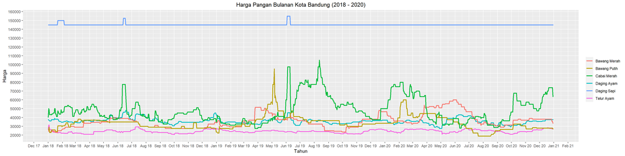

```r
ggplot(pangan, aes(x=tanggal,color=)) +
  geom_line(aes(y = daging_ayam,color = "Daging Ayam")  , size = 1) +
  geom_line(aes(y = telur_ayam,  color = "Telur Ayam"), size = 1) +
  geom_line(aes(y = daging_sapi,   color = "Daging Sapi"), size = 1) +
  geom_line(aes(y = bawang_merah, color = "Bawang Merah"), size = 1) +
  geom_line(aes(y = bawang_putih, color = "Bawang Putih"), size = 1) +
  geom_line(aes(y = cabai_merah,  color = "Cabai Merah" ),size = 1) +
    labs(x = "Tahun",
         y = "Harga",
         title = "Harga Pangan Bulanan Kota Bandung (2018 - 2020)",
         color = "")+
  theme(plot.title = element_text(hjust = 0.5))+
  scale_y_continuous(breaks = seq(10000, 160000, 10000)) +
   scale_x_date(date_breaks = "1 month",
             date_labels = "%b %y")
```

rata2 harga per bylan

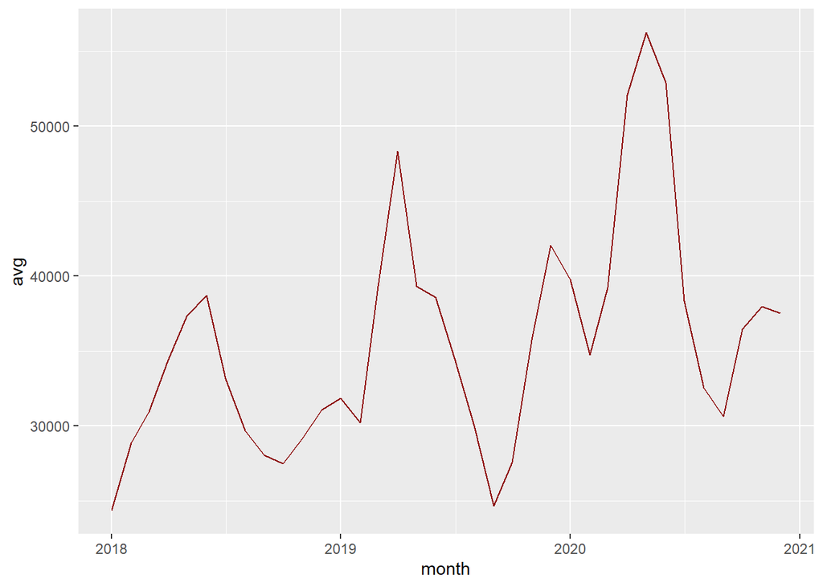

```r
sapi_monthly <- pangan %>%
  mutate(month = floor_date(pangan$tanggal, "month")) %>%
           group_by(month) %>%
           summarize(avg = mean(bawang_merah))

ggplot(sapi_monthly, aes(x=month)) +
  geom_line(aes(y = avg), color = "darkred")
```

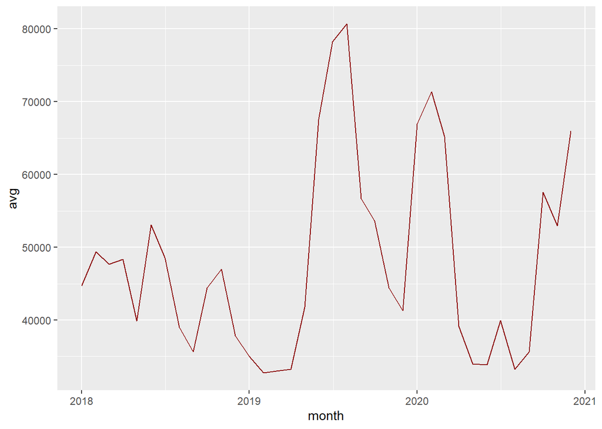

```r
cabe <- pangan %>%
  mutate(month = floor_date(pangan$tanggal, "month")) %>%
           group_by(month) %>%
           summarize(avg = mean(cabai_merah))

ggplot(cabe, aes(x=month)) +
  geom_line(aes(y = avg), color = "darkred")
```

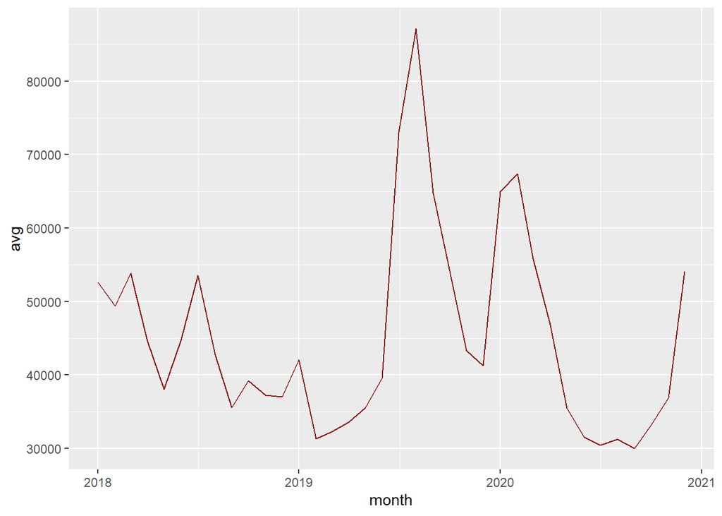

```r
cabe <- pangan %>%
  mutate(month = floor_date(pangan$tanggal, "month")) %>%
           group_by(month) %>%
           summarize(avg = mean(cabai_rawit))

ggplot(cabe, aes(x=month)) +
  geom_line(aes(y = avg), color = "darkred")
```

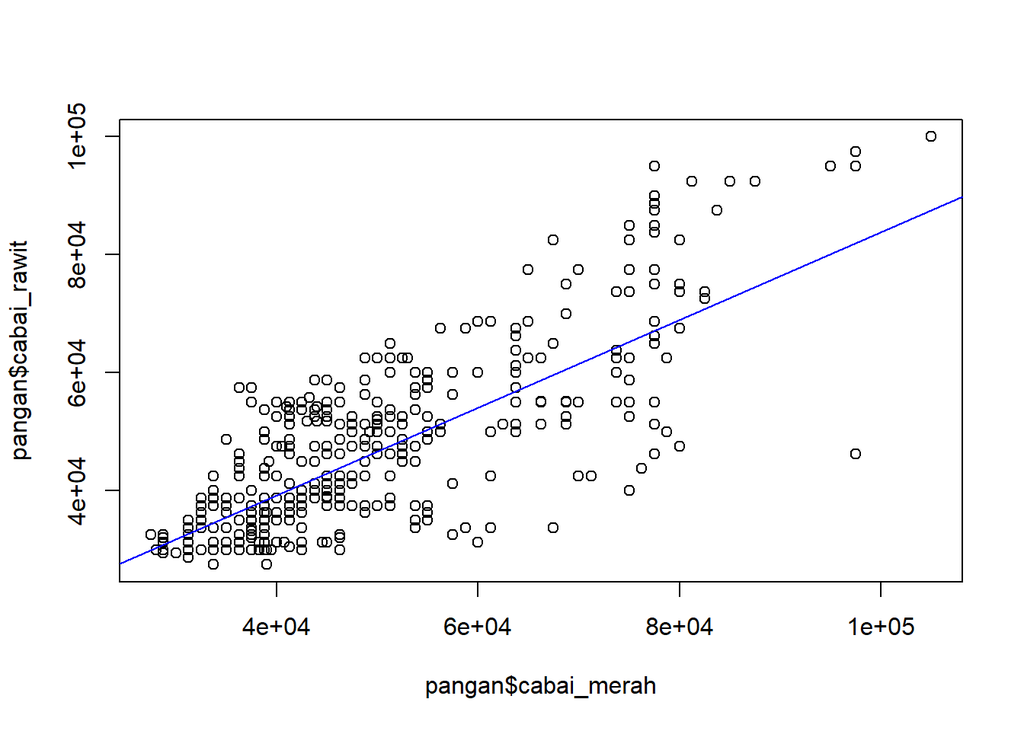

```r
plot(pangan$cabai_merah,pangan$cabai_rawit)
abline(lm(pangan$cabai_rawit ~ pangan$cabai_merah, data = pangan), col = "blue")
```

```r
sapi_monthly %>% filter(month <= "2020-12-31") %>%
  arrange(-avg)
```

```
## # A tibble: 36 x 2
##    month         avg
##    <date>      <dbl>
##  1 2020-05-01 56258.
##  2 2020-06-01 52917.
##  3 2020-04-01 52100
##  4 2019-04-01 48333.
##  5 2019-12-01 42065.
##  6 2020-01-01 39758.
##  7 2019-03-01 39323.
##  8 2019-05-01 39306.
##  9 2020-03-01 39258.
## 10 2018-06-01 38700
## # ... with 26 more rows
```

```r
sapi_monthly %>% filter(month == "2018-06-13")
```

```
## # A tibble: 0 x 2
## # ... with 2 variables: month <date>, avg <dbl>
```